# Week_2_Assignment

# Movies Ratings

## Connecting pgadmin4 with Rstudio:

### Loading Packages:

```r
library(RPostgres)
```

```r
drv <- dbDriver("Postgres")
con <-dbCanConnect(drv = RPostgres::Postgres(),
                   dbname = "Movies Ratings",
                   port = 5432,
                   user = "postgres",
                   password = "MOHAMEDChawki2018")
con
```

```
[1] TRUE
```

```r
con_1 <-dbConnect(drv = RPostgres::Postgres(),
                   dbname = "Movies Ratings",
                   port = 5432,
                   user = "postgres",
                   password = "MOHAMEDChawki2018")
con_1
```

```
<PqConnection> Movies Ratings@/tmp:5432
```

```r
dbListTables(con_1)
```

```
[1] "moviesratings"     "IMDBmoviesRatings"
```

```r
dbGetQuery(con_1, "SELECT * FROM moviesratings")
```

```
        Name 1. Avengers: Endgame: 2. The Little Mermaid 3. Booksmart
1       Hiba                    NA                     5           NA
2        Ali                    NA                    NA           NA
3       Omar                    NA                    NA           NA
4       Tony                    NA                    NA           NA
5    Youssef                     4                    NA            2
6       Adil                     3                    NA            5
7        Jor                     3                    NA           NA
8      Sarah                    NA                    NA           NA
9      Lilly                     4                    NA            5
10    Lauren                     5                    NA           NA
11   Jeannie                     5                    NA           NA
12  Jonathan                     5                    NA           NA
13    Saloua                    NA                    NA           NA
14      Sara                    NA                    NA           NA
```

[output cut: 23 more lines]

```r
ratings_df <- dbGetQuery(con_1, "SELECT * FROM moviesratings")
```

```r
library(tidyverse)
library(ggthemes)
library(gt)
library(ggplot2)
echo = FALSE
```

```r
gt(ratings_df)
```

| Name | 1. Avengers: Endgame: | 2. The Little Mermaid | 3. Booksmart | 4. Talk to Me | 5. Interstellar | 6. The Irishman |
| --- | --- | --- | --- | --- | --- | --- |
| Hiba | NA | 5 | NA | NA | NA | NA |
| Ali | NA | NA | NA | 4 | 5 | NA |
| Omar | NA | NA | NA | NA | NA | 5 |
| Tony | NA | NA | NA | NA | 3 | 5 |
| Youssef | 4 | NA | 2 | NA | NA | 5 |
| Adil | 3 | NA | 5 | NA | 5 | NA |
| Jor | 3 | NA | NA | NA | 3 | NA |
| Sarah | NA | NA | NA | 3 | NA | 4 |
| Lilly | 4 | NA | 5 | NA | 2 | NA |
| Lauren | 5 | NA | NA | NA | 3 | 3 |
| Jeannie | 5 | NA | NA | NA | 5 | 3 |
| Jonathan | 5 | NA | NA | NA | 5 | NA |
| Saloua | NA | NA | NA | NA | NA | NA |
| Sara | NA | NA | NA | NA | NA | NA |
| Christine | 5 | 4 | NA | NA | 5 | NA |
| Nancy | 4 | NA | NA | NA | NA | NA |
| Stephen | 2 | 1 | 3 | NA | NA | NA |
| Howard | 4 | NA | 3 | 4 | NA | NA |

```r
ratings_df %>%
  dplyr::select(1:7) %>%
  dplyr::slice(1:18) %>%
  gt(rowname_col = "Names of Respondents") %>%
  tab_spanner(label = "Movies Rated", columns = matches("1.|2.|3.|4.|5.|6.")) %>%
  tab_header(
    title = md("*Six Popular Movies Ratings*")
  ) %>%
  opt_stylize(style = 6)
```

*Six Popular Movies Ratings*

| Name | Movies Rated 1. Avengers: Endgame: | Movies Rated 2. The Little Mermaid | Movies Rated 3. Booksmart | Movies Rated 4. Talk to Me | Movies Rated 5. Interstellar | Movies Rated 6. The Irishman |
| --- | --- | --- | --- | --- | --- | --- |
| Hiba | NA | 5 | NA | NA | NA | NA |
| Ali | NA | NA | NA | 4 | 5 | NA |
| Omar | NA | NA | NA | NA | NA | 5 |
| Tony | NA | NA | NA | NA | 3 | 5 |
| Youssef | 4 | NA | 2 | NA | NA | 5 |
| Adil | 3 | NA | 5 | NA | 5 | NA |
| Jor | 3 | NA | NA | NA | 3 | NA |
| Sarah | NA | NA | NA | 3 | NA | 4 |
| Lilly | 4 | NA | 5 | NA | 2 | NA |
| Lauren | 5 | NA | NA | NA | 3 | 3 |
| Jeannie | 5 | NA | NA | NA | 5 | 3 |
| Jonathan | 5 | NA | NA | NA | 5 | NA |
| Saloua | NA | NA | NA | NA | NA | NA |
| Sara | NA | NA | NA | NA | NA | NA |
| Christine | 5 | 4 | NA | NA | 5 | NA |
| Nancy | 4 | NA | NA | NA | NA | NA |
| Stephen | 2 | 1 | 3 | NA | NA | NA |
| Howard | 4 | NA | 3 | 4 | NA | NA |

```r
mean1 <- round(mean(ratings_df$`1. Avengers: Endgame:`, na.rm = TRUE),2)
mean2 <- round(mean(ratings_df$`2. The Little Mermaid`, na.rm = TRUE),2)
mean3 <- round(mean(ratings_df$`3. Booksmart`, na.rm = TRUE),2)
mean4 <-round(mean(ratings_df$`4. Talk to Me`, na.rm=TRUE),2)
mean5 <- round(mean(ratings_df$`5. Interstellar`, na.rm=TRUE),2)
mean6 <- round(mean(ratings_df$`6. The Irishman`, na.rm = TRUE),2)
```

```r
Average_ratings = data.frame(Movie_Name=c('Avengers: Endgame','The Little Mermaid', 'Booksmart', 'Talk To Me', 'Interstellar', 'The Irishman'),
  Avg_ratings=c(mean1, mean2, mean3, mean4, mean5,mean6))
print(Average_ratings)
```

```
          Movie_Name Avg_ratings
1  Avengers: Endgame        4.00
2 The Little Mermaid        3.33
3          Booksmart        3.60
4         Talk To Me        3.67
5       Interstellar        4.00
6       The Irishman        4.17
```

## Visualizing the data:

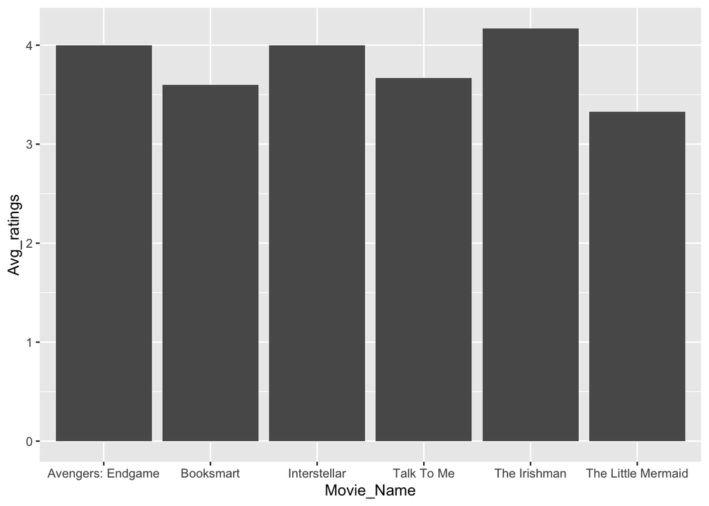

```r
ggplot(data = Average_ratings, ) + geom_bar(mapping = aes(x = Movie_Name, y = Avg_ratings ), stat = "identity")
```

```r
ratings_df2 <- data.frame(t(ratings_df))
print(ratings_df2)
```

```
                        X1   X2   X3   X4      X5   X6   X7    X8    X9    X10
Name                  Hiba  Ali Omar Tony Youssef Adil  Jor Sarah Lilly Lauren
1. Avengers: Endgame: <NA> <NA> <NA> <NA>       4    3    3  <NA>     4      5
2. The Little Mermaid    5 <NA> <NA> <NA>    <NA> <NA> <NA>  <NA>  <NA>   <NA>
3. Booksmart          <NA> <NA> <NA> <NA>       2    5 <NA>  <NA>     5   <NA>
4. Talk to Me         <NA>    4 <NA> <NA>    <NA> <NA> <NA>     3  <NA>   <NA>
5. Interstellar       <NA>    5 <NA>    3    <NA>    5    3  <NA>     2      3
6. The Irishman       <NA> <NA>    5    5       5 <NA> <NA>     4  <NA>      3
                          X11      X12    X13  X14       X15   X16     X17
Name                  Jeannie Jonathan Saloua Sara Christine Nancy Stephen
1. Avengers: Endgame:       5        5   <NA> <NA>         5     4       2
2. The Little Mermaid    <NA>     <NA>   <NA> <NA>         4  <NA>       1
3. Booksmart             <NA>     <NA>   <NA> <NA>      <NA>  <NA>       3
4. Talk to Me            <NA>     <NA>   <NA> <NA>      <NA>  <NA>    <NA>
5. Interstellar             5        5   <NA> <NA>         5  <NA>    <NA>
6. The Irishman             3     <NA>   <NA> <NA>      <NA>  <NA>    <NA>
                         X18
Name                  Howard
1. Avengers: Endgame:      4
2. The Little Mermaid   <NA>
3. Booksmart               3
4. Talk to Me              4
5. Interstellar         <NA>
6. The Irishman         <NA>
```

## Conclusion:

After calculating the Global Baseline Estimate using Excel, I found it was 3.89. Considering 3.89 as an average threshold, the most recommended movies are “Avengers: Endgame”, “Interstellar”, and ” The Irishman”. The movies that were rated have different Genres which makes it though to recommend any movie to any of the respondents, especially to Saloua and Sara. They both happened to not watch any of these movies. Based on the average ratings of each movie, the Irishman got the greatest average of all “4.17”

## References:

- *“A Simple Guide On Connecting Rstudio to a PostgreSQL Database”* https://medium.com/geekculture/a-simple-guide-on-connecting-rstudio-to-a-postgresql-database-9e35ccdc08be
- “*Great Looking Tables: gt (v0.2)“* https://posit.co/blog/great-looking-tables-gt-0-2/